# Hidden Markov Models: Direct maximization, dealing with missing data in the likelihood and state decoding

Marco Gallegos Herrada

8/11/2022

# 1 Tutorial goals

In yesterday’s tutorial, we addressed how to simulate and visualize a hidden state sequence and an observable process derived from for a given $\eta = (\pi,\Gamma,\Lambda)$, and the computation of $l(\eta)$ through the forward algorithm. In this tutorial, we will deal with technical issues for maximimizing the likelihood, the computation of the likelihood when there are data missing and the implementation of the forward/backward algorithm for state decoding. More specificly:

- Modifying the likelihood when data are missing
  - Missing observations
  - Interval censoring
- Direct maximization
  - Dealing with parameter constrains
  - Bayesian estimation
- Implementation of the backward algorithm for the computation of the probabilities

- State decoding
  - Local decoding

For this purpose, we will reuse the sequence of states and observations generated in yesterday’s tutorial:

```r
gdata = readRDS("gdata.rds")

states_seq = gdata$states
obs_seq = gdata$observations
ntimes = 100

# Initial distribution
pi_ = c(2/3,1/3)

# Transition probability matrix
Gamma.matrix = matrix(c(.9,.2,.1,.8),2,2)

lambda = c(3,10)

source("aux-fcts.R")
```

# 2 Modyfing the likelihood

## 2.1 The likelihood when data are missing

It’s pausible that, when working with time series data, some observations are missing. However, in the case of HMM, the adjustemnt of the likelihood computation if data are missing turns out to be relatively simple.

Let’s consider, for example, that one has available the observations $x_1, x_3,x_6,x_8,x_{9},\ldots, x_{T}$ of an HMM, but $x_2,x_4,x_5,x_7$ are missing. Then the likelihood of the observation is given by

$$\begin{align*}
P(Y_1=y_1 &, Y_3=y_3,Y_6=y_6,Y_8=y_8,Y_{9}=y_{9},\ldots, Y_T=y_{T})\\
= &\sum \delta_{x_1}\gamma_{x_1,x_3}(2)\gamma_{x_3,x_6}(3)\gamma_{x_6,x_8}(2)\gamma_{x_8,x_9}\cdots,\gamma_{x_{T-1},x_T}\\
&\times p_{x_1}(y_1)p_{x_3}(y_3)p_{x_6}(y_6)p_{x_8}(y_8)\cdots p_{x_T}(y_T)
\end{align*}$$

where $\gamma_{ij}(k)$ denotes a $k-$step transition probability, and the sum is taken over all indices $x_t$ other than $x_2,x_4,x_5,x_7$. But this is in fact

$$\begin{align*}
&= \pi P(y_1)\Gamma^2 P(y_3) \Gamma^{3} P(y_6) \Gamma^{2} P(y_8) \Gamma P(y_9) \cdots \Gamma P(y_T)1'.
\end{align*}$$

From this, we can conclude that, in general, in the expression for the likelihood the diagonal matrices $P(y_t)$ corresponding to missing observations $y_t$ can be replaced by the identity matrix!

Given the above, now let’s consider our original sequence of observations, but now we will assume that there’s some missing observations:

```r
set.seed(50)
missing_id = sample(1:ntimes,30)

obs_seq_missing = obs_seq

obs_seq_missing[missing_id] = NA

obs_seq_missing
```

```
##   [1]  1  3  2  2  2  6 NA NA  1 NA NA  5 NA  6  2 NA  3 NA  1  3 NA  2  2  2  3
##  [26]  2  4 NA  2  3 NA NA  4 NA  2  0 NA  3 NA  9 11  8  6  8 15 NA NA  7 15 10
##  [51] 11 NA 14 10  2 NA NA  1  2  0  1 NA NA 10  6  4 NA NA  3 NA NA  2  3  1  2
##  [76]  4  5  5  3  4  2  3 NA NA  8  8  9  9 10 10 NA 12  9  3 NA  3  3 NA  2  2
```

Using the approach shown above, compute the likelihood of the sequence with missing data.

```r
#########################################################
### Enter your code for computing the likelihood here ###
#########################################################

obs_is_missing = is.na(obs_seq_missing)

forward_algorithm_missing = function(observations,time,init = pi,tpm=Gamma.matrix,parameters=lambda){

  # This is for time t = 1

  obs_is_missing = is.na(obs_seq_missing)

  if(obs_is_missing[1]){
    alpha = init * c(1,1)
  } else{
    alpha = init * dpois(observations[1],parameters)
  }


  #Alternative way of computing alpha for t =1
  #alpha = init %*% diag(dpois(observations[1],parameters))

  if(time > 1){
    for (i in 2:time) {
      if(obs_is_missing[i]){

        alpha = alpha %*% tpm*c(1,1)

      } else{

        alpha = alpha %*% tpm*dpois(observations[i],parameters)
      }

      #Alternative way of computing alpha for t > 1
      #alpha = alpha %*% tpm%*%diag(dpois(observations[i],parameters))
    }
  }
  return(alpha)
}


log(sum(forward_algorithm_missing(obs_seq_missing,ntimes)))
```

```
## [1] -154.1718
```

## 2.2 The likelihood when observations are interval-censored

Assume that some of the missing observations are interval-censored. For instance, the value of $x_t$ may be known only for $t \neq 1,3,8$, with the information

$$\begin{align*}
y_1 \leq 5,\\
2 \leq y_3 \leq 3\\
y_8 > 10,
\end{align*}$$
available about the remaining observations. In this scenario one replaces the diagonal matrices $P(y_i)$ $(i = 1,3,8)$ in the likelihood expression by the matrices

$$\begin{align*}
\text{diag} (P(Y_1 \leq 5 \mid X_1 = 1), P(Y_1 \leq 5 \mid X_1 = 2)),\\
\text{diag} (P(2 \leq Y_2 \leq 3 \mid X_1 = 1), P(2 \leq Y_2 \leq 3 \leq 5 \mid X_1 = 2)),\\
\text{diag} (P(Y_8 > 10 \mid X_1 = 1), P(Y_8 > 10 \mid X_1 = 2)).
\end{align*}$$

```r
#################################################################
### Compute the likelihood when given interval censoring here ###
#################################################################

id_censored = c(1,3,8)
obs_is_censored = 1:10 %in% id_censored
obs_is_censored
```

```
##  [1]  TRUE FALSE  TRUE FALSE FALSE FALSE FALSE  TRUE FALSE FALSE
```

```r
names(obs_is_censored) = paste0("x",1:10)
names(obs_is_censored[1])
```

```
## [1] "x1"
```

```r
intervals = list(x1 = ppois(5,lambda),
            x3 = ppois(3,lambda) - ppois(1,lambda),
            x8 = 1-ppois(10,lambda))


if(obs_is_censored[1]){
  interval_xi = names(obs_is_censored[1])
  alpha = pi_ * intervals[[interval_xi]]
  } else{
    alpha = pi_ * dpois(obs_seq[1],lambda)
    }

for(i in 2:10){
  if(obs_is_censored[i]){
    interval_xi = names(obs_is_censored[i])
    alpha = alpha %*% Gamma.matrix * intervals[[interval_xi]]
  } else{
    alpha = alpha %*% Gamma.matrix*dpois(obs_seq[i],lambda)

  }
}

alpha
```

```
##              [,1]         [,2]
## [1,] 3.617535e-09 4.453244e-12
```

# 3 Direct maximization

```r
log.likelihood = function(theta.star,observations=obs_seq){

  theta = c(plogis(theta.star[1]),plogis(theta.star[2]),exp(theta.star[3]),exp(theta.star[4]))
  # This is for time t = 1
  tpm = diag(theta[1:2])
  tpm[1,2] = 1-tpm[1,1]
  tpm[2,1] = 1-tpm[2,2]

  pi = solve(t(diag(2)-tpm + matrix(1,2,2)),c(1,1))
  lambda = theta[3:4]

  alpha = pi %*% diag(dpois(observations[1],lambda))

  for (i in 2:length(obs_seq)) {
    #alpha = alpha %*% tpm*dpois(observations[i],parameters)

    #Alternative way of computing alpha for t > 1
    alpha = alpha %*% tpm%*%diag(dpois(observations[i],lambda))
  }
  return(-log(sum(alpha))) # returns -log(L) since nlm() can only minimize!
}


set.seed(30)
dgammas = runif(2)
lambdas = runif(1)
lambdas = c(5,12)

theta.star = c(qlogis(dgammas),log(lambdas))
```

```r
mod = nlm(log.likelihood,theta.star,observations=obs_seq,print.level = 2)
```

```
## iteration = 0
## Step:
## [1] 0 0 0 0
## Parameter:
## [1] -2.21082259 -0.04708155  1.60943791  2.48490665
## Function Value
## [1] 376.7274
## Gradient:
## [1] -29.540292   4.452901 126.894883 161.670968
##
## iteration = 1
## Step:
## [1]  0.1475455 -0.0222410 -0.6338045 -0.8075013
## Parameter:
## [1] -2.06327708 -0.06932255  0.97563344  1.67740535
## Function Value
## [1] 285.1804
## Gradient:
## [1]  -2.047162  -5.620732  11.329215 -56.162427
##
## iteration = 2
## Step:
## [1]  0.00822682  0.02016100 -0.04449045  0.19812546
## Parameter:
## [1] -2.05505026 -0.04916155  0.93114298  1.87553081
## Function Value
## [1] 278.8151
## Gradient:
## [1] -5.08088997 -3.59563677 14.15655152  0.07996324
##
## iteration = 3
## Step:
## [1]  0.02676715  0.01912195 -0.08173078  0.01781291
## Parameter:
## [1] -2.0282831 -0.0300396  0.8494122  1.8933437
## Function Value
## [1] 277.6864
## Gradient:
## [1] -5.608231 -3.701249  9.125543  4.108661
##
```

[output cut: 195 more lines]

```
## Function Value
## [1] 226.8716
## Gradient:
## [1] -0.0030240379  0.0022390821 -0.0009849849 -0.0007146058
##
## iteration = 24
## Parameter:
## [1] 3.022706 1.890537 1.063717 2.283120
## Function Value
## [1] 226.8716
## Gradient:
## [1]  4.438092e-05 -6.638869e-05 -1.026554e-04 -8.435189e-05
##
## Relative gradient close to zero.
## Current iterate is probably solution.
```

```r
c(plogis(mod$estimate[1:2]),exp(mod$estimate[3:4]))
```

```
## [1] 0.9535894 0.8688167 2.8971185 9.8072328
```

## 3.1 Bayesian inference

```r
library(cmdstanr)
model = cmdstan_model("hmm_poisson.stan")
data = list(N=ntimes,K=2,y=obs_seq)
fit = model$sample(data)
```

[output not shown]

[output cut: 43 more lines]

```
## Chain 4 Iteration: 1100 / 2000 [ 55%]  (Sampling)
## Chain 4 Iteration: 1200 / 2000 [ 60%]  (Sampling)
## Chain 4 Iteration: 1300 / 2000 [ 65%]  (Sampling)
## Chain 4 Iteration: 1400 / 2000 [ 70%]  (Sampling)
## Chain 4 Iteration: 1500 / 2000 [ 75%]  (Sampling)
## Chain 4 Iteration: 1600 / 2000 [ 80%]  (Sampling)
## Chain 4 Iteration: 1700 / 2000 [ 85%]  (Sampling)
## Chain 4 Iteration: 1800 / 2000 [ 90%]  (Sampling)
## Chain 4 Iteration: 1900 / 2000 [ 95%]  (Sampling)
## Chain 4 Iteration: 2000 / 2000 [100%]  (Sampling)
## Chain 4 finished in 2.1 seconds.
##
## All 4 chains finished successfully.
## Mean chain execution time: 2.3 seconds.
## Total execution time: 9.7 seconds.
```

```r
print(fit)
```

```
##    variable    mean  median   sd  mad      q5     q95 rhat ess_bulk ess_tail
##  lp__       -234.01 -233.69 1.42 1.20 -236.79 -232.36 1.00     1923     2748
##  theta[1,1]    0.93    0.93 0.04 0.04    0.86    0.98 1.00     3411     2374
##  theta[2,1]    0.16    0.16 0.08 0.08    0.06    0.30 1.00     3366     2325
##  theta[1,2]    0.07    0.07 0.04 0.04    0.02    0.14 1.00     3411     2374
##  theta[2,2]    0.84    0.84 0.08 0.08    0.70    0.94 1.00     3366     2325
##  lambda[1]     2.84    2.84 0.23 0.24    2.47    3.23 1.00     3545     2499
##  lambda[2]     9.76    9.76 0.63 0.64    8.77   10.83 1.00     4260     3133
```

# 4 Backward algorithm

**a)** Create a function that computes the backward algorithm $\beta'_t$ for any time $t = 1,...,T$. **b)** Show that, for $t=43$, in effect $\alpha_{43}\beta'_{43} = L_T$.

**4a)** Create a function that computes the backward algorithm $\beta'_t$ for any time $t = 1,...,T$.

```r
#######################################################################
### Include your function that computes the backward algorithm here ###
#######################################################################

### Tip: Compute (beta_t)' it's easier than computing beta_t!

# Function that computes the backward algorithm (here we are calculating beta')

backward_algorithm = function(observations,time,
                              total.time = ntimes,init = pi,tpm=Gamma.matrix,parameters=lambda){

  # This is for time t = T
  beta = rep(1,2)

  # For t < T we can calculate beta in the following way
  if(time < total.time){
    for (i in total.time:(time+1)) {

      beta = tpm%*%diag(dpois(observations[i],parameters))%*%beta

    }
  }

  return(beta)

}


### Alternative way to compute the backward algorithm

backward_algorithm_alternative = function(observations,
                                          time,total.time = ntimes,
                                          init = pi,tpm=Gamma.matrix,parameters=lambda){

  # This is enought for t = T
  beta = diag(2)

  if(time < total.time){
    for (i in (time+1):total.time) {

      beta = beta%*%tpm%*%diag(dpois(observations[i],parameters))

    }
  }
  beta = beta%*%c(1,1)
  return(beta)
}
```

**4b)** Show that, for $t=43$, in effect $\alpha_{43}\beta'_{43} = L_T$.

```r
##############################
### Include your code here ###
##############################

forward_algorithm(obs_seq,43)
```

```
##              [,1]         [,2]
## [1,] 8.719907e-41 4.044699e-40
```

```r
alpha43 = forward_algorithm(obs_seq,43)
beta_transpose43 =backward_algorithm(obs_seq,43)

alpha43%*%beta_transpose43
```

```
##               [,1]
## [1,] 6.988322e-100
```

```r
log(alpha43%*%beta_transpose43)
```

```
##           [,1]
## [1,] -228.3143
```

# 5 State decoding

## 5.1 Local Decoding

From the introduction of HMM previously provided, we know that for every $t=1,\ldots , T$

$$\begin{align*}
\alpha_{i,t}\beta_{i,t} = P(Y_{1:T}=y_{1:T} , X_t = i).
\end{align*}$$

And thus, the conditional distribution of $X_t$ given the observations can be obtained as

$$\begin{align*}
P(X_t = i \mid Y_{1:T} = y_{1:T}) &= \dfrac{P(X_t = i, Y_{1:T} = y_{1:T})}{P(Y_{1:T} = y_{1:T})}\\
&= \dfrac{\alpha_t(i)\beta_t(i)}{\mathcal{L}}.
\end{align*}$$

Use your functions for computing the forward and backward algorithms from previous tutorial to estimate $P(X_t = i \mid Y_{1:T} = y_{1:T})$ for every time $t=1,\ldots, T$ and every state $i=1,2$. Plot the estimated probabilities for the state 1 for every $t$.

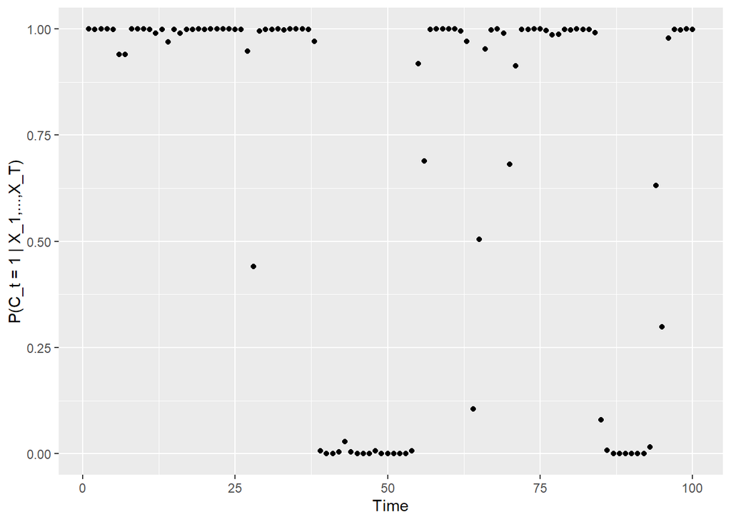

```r
#################################################
### Include your code for local decoding here ###
#################################################

library(ggplot2)

alpha_t = matrix(NA,ntimes,2)
beta_t = matrix(NA,ntimes,2)

for(i in 1:ntimes){
  alpha_t[i,] = forward_algorithm(obs_seq,i)
  beta_t[i,] = backward_algorithm(obs_seq,i)

}

### Likelihood
L_T = sum(forward_algorithm(obs_seq,ntimes))
C = alpha_t*beta_t/L_T
colnames(C) = c("state1","state2")

C = as.data.frame(C)

ggplot(C,aes(x=1:ntimes,y=state1)) + geom_point() + xlab("Time") + ylab("P(C_t = 1 | X_1,...,X_T)")
```

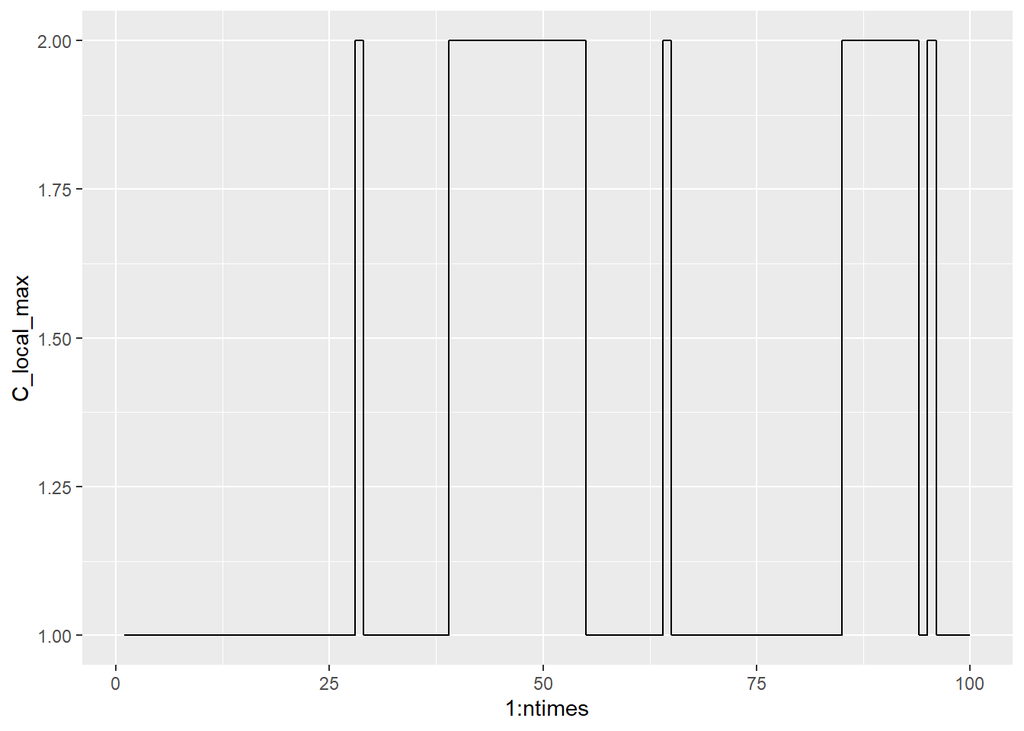

```r
C_local_max = apply(C,1,function(x) which(max(x) == x))
ggplot(C,aes(x=1:ntimes,y=C_local_max)) + geom_step()
```

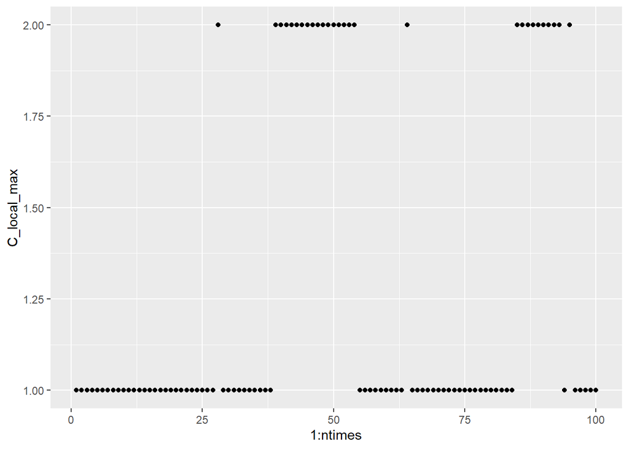

```r
ggplot(C,aes(x=1:ntimes,y=C_local_max)) + geom_point()
```